# U.S.A Incomes by Occupation and Gender

by Roey Nir and Tamar Tal

24.6.2021

#### *introduction*

In this paper we will analyze the [‘Ask A Manager Salary Survey 2021’](https://docs.google.com/spreadsheets/d/1IPS5dBSGtwYVbjsfbaMCYIWnOuRmJcbequohNxCyGVw/edit?resourcekey#gid=1625408792) data set.

This data set contains information regarding people’s income and several different variable as you will see below.  
We would like to examine the effects of different variables such as occupation, gender and years of experience on one’s annual salary in three major fields: Hi-tech, Health care and Higher education.

#### *Data import and tidying*

First, we need to adjust the data set - here are the main adjustments we did:

- We filtered the data so we can work with information regarding the USA and the relevant occupation.
- We selected the relevant columns for our hypothesis and questions.
- We deleted ‘NA’ values, unclassified gender and unreasonable salaries.

#### *Transformation*

We did a little bit of transformation so it will be easier for us to work with the data and for you to go over it – here are the main changes we did:

- We divided the ‘Annual salary’ column so that we will work with smaller numbers.
- We changed the ‘highest level of education completed’ values to degrees name that matches the types of degrees in Israel.
- We changed the columns names according to the transformations above.

Here, take a little glimpse…

```
## Rows: 6,682
## Columns: 7
## $ how_old_are_you                          <chr> "25-34", "25-34", "45-54", "3~
## $ industry                                 <chr> "Higher Education", "Higher E~
## $ annual_salary                            <dbl> 55.000, 62.000, 112.000, 62.0~
## $ overall_years_of_professional_experience <chr> "5-7 years", "8 - 10 years", ~
## $ highest_level_of_education_completed     <chr> "Master's Degree", "Master's ~
## $ gender                                   <chr> "Woman", "Man", "Woman", "Wom~
## $ race                                     <chr> "White", "White", "White", "H~
```

#### *Visualizations & Modeling*

The next plots will show the difference between man’s and woman’s average annual salary in each field:

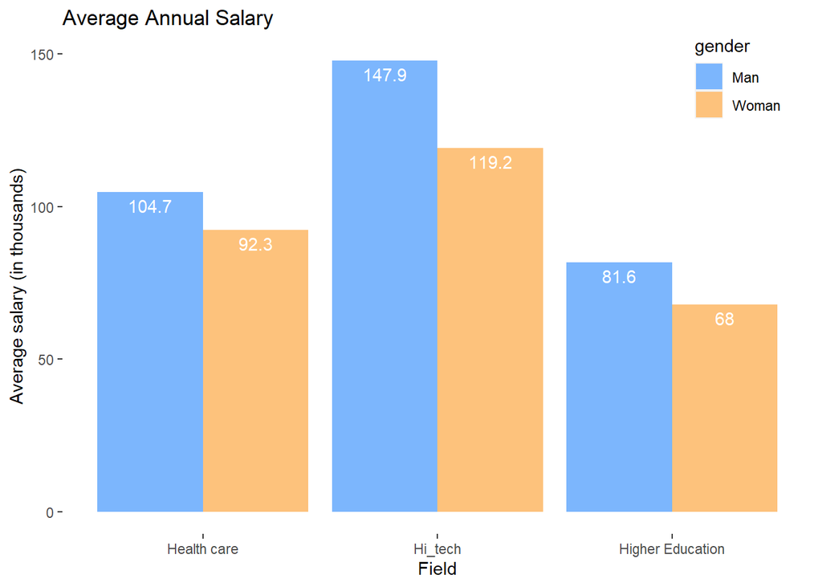

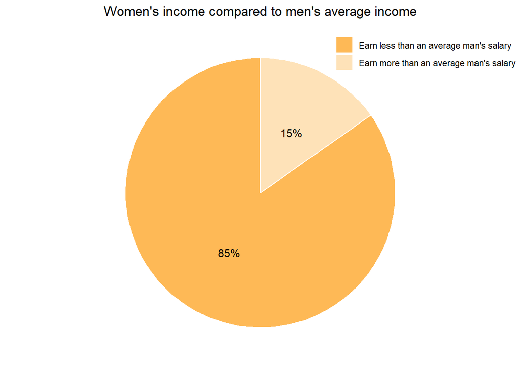

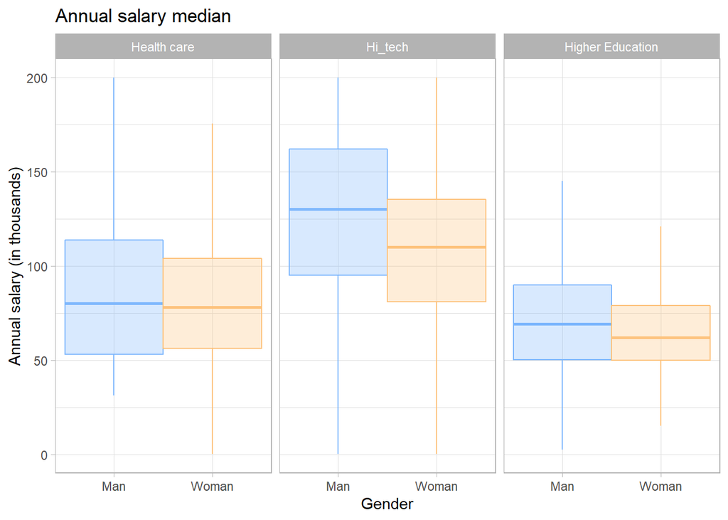

As we can see in these charts, in every field, woman’s income is much lower.  
We can also see the low percentage of woman whose salary is equal or higher than the average salary of man.

##### *First model*

Clearly gender has an effect on one’s income. Now we would like to use unpaired two samples t-test to show our hypothesis with a significance level of 0.05.

*Our hypothesis:*  
$H_0$= there is no income difference between genders.  
$H_1$= man’s income is higher than woman’s income.

```
##
##  F test to compare two variances
##
## data:  t_test_data$annual_salary by t_test_data$gender
## F = 2.1671, num df = 1768, denom df = 4912, p-value < 2.2e-16
## alternative hypothesis: true ratio of variances is not equal to 1
## 95 percent confidence interval:
##  2.008135 2.341974
## sample estimates:
## ratio of variances
##           2.167111
```

As we can see, the p-value equals to 2.2e-16 and smaller than 0.05, therefore, we **can reject** the $H_0$ assumption, which means the variances are different.

Let`s move on to the one tailed t-test:

```
##
##  Welch Two Sample t-test
##
## data:  t_test_data$annual_salary by t_test_data$gender
## t = 17.486, df = 2380.7, p-value < 2.2e-16
## alternative hypothesis: true difference in means is greater than 0
## 95 percent confidence interval:
##  37.96195      Inf
## sample estimates:
##   mean in group Man mean in group Woman
##           136.36604            94.46071
```

The p-value equals to 2.2e-16 and smaller than 0.05, therefore, we **can reject** the $H_0$ assumption, which means that men income is higher than women income.

#### *More visualizations…*

The next question we want to discuss, is if there is a linear connection between one`s total years of experience and his annual income.

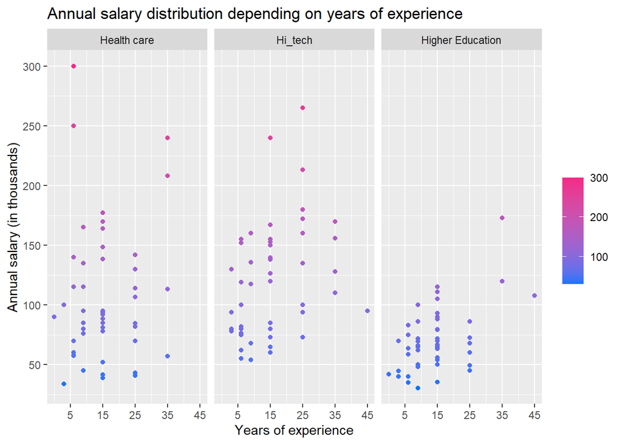

For this part, we created a new variable with the necessary columns and changed the ‘overall years of professional experience’ column to the middle value of the given range.  
Next we used the function ‘sample_n’ to sample 50 random rows from each industry, so that way we can work with a database big enough but not too big.

At first, we thought it would be easy to see a correlation between years of experience and salary but while looking at the plot, we see that this is not the case; there are plenty of people with many years of experience and lower salaries.

We will now try to test this with linear regression model.

##### *second model*

We are using linear regression model with significance level of 0.05. Of course the dependent variable $Y$ is the annual salary and the independent variable $X$ is the number of years of experience.

*Our hypothesis:*  
$H_0$= there in no linear connection between $X$ and $Y$.  
$H_1$= The larger the $X$, the larger the $Y$.

Another way to write the hypothesis is:  
$H_0$: $\beta_1$=0  
$H_1$: $\beta_1$>0

We chose to examine each field individually because the salary distribution between the fields is different:

1. Health care:

```
##
## Call:
## lm(formula = annual_salary ~ overall_years_of_professional_experience,
##     data = health)
##
## Residuals:
##    Min     1Q Median     3Q    Max
## -71.12 -31.65 -13.38  26.88 197.84
##
## Coefficients:
##                                          Estimate Std. Error t value Pr(>|t|)
## (Intercept)                               99.0119    15.8205   6.258 1.01e-07
## overall_years_of_professional_experience   0.5243     0.9019   0.581    0.564
##
## (Intercept)                              ***
## overall_years_of_professional_experience
## ---
## Signif. codes:  0 '***' 0.001 '**' 0.01 '*' 0.05 '.' 0.1 ' ' 1
##
## Residual standard error: 56.93 on 48 degrees of freedom
## Multiple R-squared:  0.006991,   Adjusted R-squared:  -0.0137
## F-statistic: 0.3379 on 1 and 48 DF,  p-value: 0.5637
```

As we can see, the p-value equals to 0.5637 and bigger than 0.05, therefore, we **cannot reject** the $H_0$ assumption.  
The conclusion is that there is no linear connection between years of experience and annual salary in Healthcare field.

2. Hi-tech:

```
##
## Call:
## lm(formula = annual_salary ~ overall_years_of_professional_experience,
##     data = tech)
##
## Residuals:
##     Min      1Q  Median      3Q     Max
## -68.574 -38.666  -1.951  30.805 131.353
##
## Coefficients:
##                                          Estimate Std. Error t value Pr(>|t|)
## (Intercept)                                96.240     12.036   7.996 2.23e-10
## overall_years_of_professional_experience    1.496      0.653   2.291   0.0264
##
## (Intercept)                              ***
## overall_years_of_professional_experience *
## ---
## Signif. codes:  0 '***' 0.001 '**' 0.01 '*' 0.05 '.' 0.1 ' ' 1
##
## Residual standard error: 46.34 on 48 degrees of freedom
## Multiple R-squared:  0.0986, Adjusted R-squared:  0.07982
## F-statistic: 5.251 on 1 and 48 DF,  p-value: 0.02637
```

Here the p-value equals to 0.02637 and smaller than 0.05, therefore, we **can reject** the $H_0$ assumption.  
In contrast to the last field there is a positive linear connection between years of experience and annual salary in Hi-tech field.

3. Higher education:

```
##
## Call:
## lm(formula = annual_salary ~ overall_years_of_professional_experience,
##     data = education)
##
## Residuals:
##    Min     1Q Median     3Q    Max
## -42.97 -15.14  -2.01  16.06  69.10
##
## Coefficients:
##                                          Estimate Std. Error t value Pr(>|t|)
## (Intercept)                                48.151      6.100   7.894 3.19e-10
## overall_years_of_professional_experience    1.593      0.367   4.340 7.30e-05
##
## (Intercept)                              ***
## overall_years_of_professional_experience ***
## ---
## Signif. codes:  0 '***' 0.001 '**' 0.01 '*' 0.05 '.' 0.1 ' ' 1
##
## Residual standard error: 22.76 on 48 degrees of freedom
## Multiple R-squared:  0.2819, Adjusted R-squared:  0.2669
## F-statistic: 18.84 on 1 and 48 DF,  p-value: 7.295e-05
```

Again, there is a positive linear connection between the number of years of experience and the annual salary.  
We can see that the p- value equals to 0.00007 and smaller than 0.05.

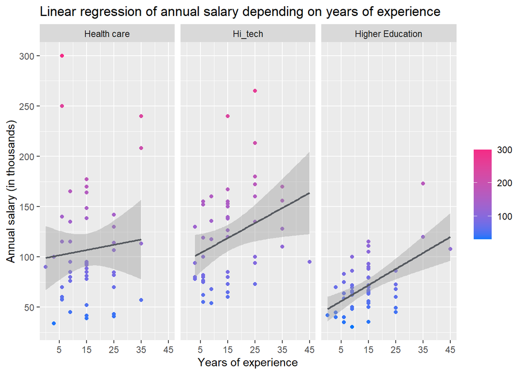

#### *Summary*

We examined a couple of question regarding income, gender and occupation.  
We saw the wage gap between genders through plots and a t-test and we got an general idea about the meaning of experience in the market using regression analysis.  
In addition, this project gave us a chance to practice different methods in R programming and also some experience that will help us in the future.

Thank you!